# VME Analysis_R manuscript

Felix Klotzsche, Sven Ohl

8 6 2021

## Intro

This file prints relevant statistics and plots of the vMemEcc manuscript. Please note, analyses and plots produced in Python are not included here - but in a separate notebook. The most relevant chunkcs of the source code are included in this file as well. For the full code base, please refer to the [repository on GitHub](https://github.com/eioe/vmemecc).

## Requirements

We ran these analyses using version 4.1.0 (2021-05-18) in RStudio v1.4.1717.

## Init workspace

Loads packages, custom functions, custom themes, and data. Data is made availbale in the workspace as data frame `data_behav`.

- **ppid** (chr): subject id (e.g., “VME_S09”)
- **trial_num** (num): index of the trial in the experiment (includes all trials from all blocks; also training) “perception” block: 11-82  
  vSTM block (“experiment”): 93-812
- **block_num** (num): index of the block
- **c_StimN** (num): number of memory items (2 or 4)
- **c_Ecc** (num): stimulus eccentricity (4, 9, 14)
- **c_ResponseCorrect** (logi): correctness of response in this trial
- **c_ResponseTime** (num): RT
- **BlockStyle** (chr): denotes if trial was in “perception” or vSTM (“experiment”) block
- **CDA_amp_times** (num): avg. CDA amplitude in this trial (see paper for spec. of ROI and time window).
- **PNP_amp_times** (num): avg. PNP amplitude in this trial (see paper for spec. of ROI and time window)
- **alphapwr_diff_retent** (num): avg. lateralized alpha power in this trial (see paper for spec. of freq. band, ROI and time window)

```r
#--------------------------------------------------------------------------
# Run main script for analysis for:
#  vMemEcc
#--------------------------------------------------------------------------

library(here)
library(knitr)


#--------------------------------------------------------------------------
# Define pathes
path_global         <- here('../..')
path_r_data       <- file.path(path_global, 'Data/DataR')
path_scripts_sven <- file.path(here('Workflow_Sven',
                                    'osf_experiment1',
                                    '_RScripts'))
path_extracted_vars <- file.path(here('../VME_extracted_vars.json'))
  # path_global, 'Writing',
  #                            'Other',
  #                            'VME_extracted_vars.json')

#--------------------------------------------------------------------------
## load packages & custom utils:
source(here("Utils", "load_packages.R"))
source(file.path(path_scripts_sven,"loadPackages.R"))
source(here('Utils', 'print_output.R'))
source(here('Utils', 'utils_report.R'))
source(here('Utils', 'calc_conf_intervalls.R'))


#--------------------------------------------------------------------------

#--------------------------------------------------------------------------
## define colors
source(file.path(path_scripts_sven, "loadColors.R"))
#--------------------------------------------------------------------------

#--------------------------------------------------------------------------
## load function to compute confidence intervals
source(file.path(path_scripts_sven,"loadFunctions.R"))
source(file.path(here('Utils', 'load_functions.R')))
#--------------------------------------------------------------------------

#--------------------------------------------------------------------------
## load theme
source(file.path(path_scripts_sven, "loadTheme.R"))
#--------------------------------------------------------------------------

#--------------------------------------------------------------------------
## load data, assign names for columns and define variable type
source(file.path(here('Utils', 'load_data.R')))
#--------------------------------------------------------------------------


# Write
extract_var("r_version", "v4.1.0", exp_format = "%s")
extract_var("rstudio_version", "v1.4.1717", exp_format = "%s")
```

## Summary stats:

**Extract relevants descriptives about the data set.**

```r
# Total number of experimental trials (720 x n):

n_rej_subs <- 3
print(str_glue("N rejected subjects: {n_rej_subs}"))
```

```
## N rejected subjects: 3
```

```r
n_subs_analyzed <- length(unique(data_behav$ppid))
n_tot_trials <- 720 * (n_subs_analyzed + n_rej_subs)
n_tot_trials_prerej <- 720 * n_subs_analyzed
print(str_glue("Total number of recorded experimental trials (720 x {n_subs_analyzed + n_rej_subs}): {n_tot_trials}"))
```

```
## Total number of recorded experimental trials (720 x 24): 17280
```

```r
print(str_glue("Total number of experimental trials after subject rejection (720 x {n_subs_analyzed}): {n_tot_trials_prerej}"))
```

```
## Total number of experimental trials after subject rejection (720 x 21): 15120
```

```r
n_tot_trials_postrej <- data_behav %>% filter(BlockStyle == 'experiment') %>%  drop_na() %>% nrow()
n_trials_rejected <- n_tot_trials_prerej - n_tot_trials_postrej
print(str_glue("Total number of trials after rejection: {n_tot_trials_postrej} ({n_trials_rejected} trials rejected)"))
```

```
## Total number of trials after rejection: 13384 (1736 trials rejected)
```

```r
data_behav_per_task <- vector(mode = "list", length = 2)
data_behav_per_task[['exp']] <- data_behav %>%
  filter(BlockStyle == 'experiment') %>%
  drop_na()
data_behav_per_task[['perc']] <- data_behav %>%
  filter(BlockStyle == 'perception') %>%
  # select(!contains(c('CDA_amp', 'PNP_amp', 'alphapwr_diff_retent'))) %>%
  select(ppid, trial_num, block_num, c_StimN, c_Ecc, c_ResponseCorrect, c_ResponseTime, BlockStyle) %>%
  drop_na()


# Summary remaining trials:
summary_rem_trials_per_sub <- data_behav_per_task[['exp']] %>%
  group_by(ppid) %>%
  summarise(n_trials_remaining = n(),
            perc_trials_remaining = n_trials_remaining*100 / 720,
            .groups = "drop")



print(str_glue("Remaining trials per subject (percentage):
           mean: {mean(summary_rem_trials_per_sub$n_trials_remaining)} ({format(mean(summary_rem_trials_per_sub$perc_trials_remaining), digits=3)}%)
           range:  {min(summary_rem_trials_per_sub$n_trials_remaining)} ({format(min(summary_rem_trials_per_sub$perc_trials_remaining), digits=3)}%) - {max(summary_rem_trials_per_sub$n_trials_remaining)} ({format(max(summary_rem_trials_per_sub$perc_trials_remaining), digits=3)}%)\n\n"))
```

```
## Remaining trials per subject (percentage):
##            mean: 637.333333333333 (88.5%)
##            range:  529 (73.5%) - 710 (98.6%)
```

```r
acc_overall <- vector(mode = "list", length = 2)
stats_overall <- vector(mode = "list", length = 2)
acc_per_memLoad <- vector(mode = "list", length = 2)
stats_memLoad <- vector(mode = "list", length = 2)
acc_per_ecc <- vector(mode = "list", length = 2)
stats_ecc <- vector(mode = "list", length = 2)


for (task in c('perc', 'exp')) {

  if (task == "exp") {
    outvars <- list("c_ResponseCorrect",
                    "CDA_amp_clustertimes",
                    "PNP_amp_clustertimes",
                    "alphapwr_diff_retent",
                    "maxDecodScore_sensorspace",
                    "maxDecodScoreTime_sensorspace",
                    "maxDecodScore_csp",
                    "maxDecodScoreTime_csp")
  } else {
    outvars <- list("c_ResponseCorrect")
  }

  for (outvar in outvars) {

    scaler = switch (outvar,
                     "c_ResponseCorrect" = 100,
                     "alphapwr_diff_retent" = 1e12,
                     "maxDecodScoreTime_sensorspace" = 1000,
                     "maxDecodScoreTime_csp" = 1000,
                     1
                    )
    dv_str = switch (outvar,
                 "c_ResponseCorrect" = "mem_acc",
                 "alphapwr_diff_retent" = "alphalat",
                 "CDA_amp_clustertimes" = "cda",
                 "PNP_amp_clustertimes" = "pnp",
                 "maxDecodScore_sensorspace" = "decod_sensorspace_maxscore",
                 "maxDecodScoreTime_sensorspace" = "decod_sensorspace_maxscoretime",
                 "maxDecodScore_csp" = "decod_csp_maxscore",
                 "maxDecodScoreTime_csp" = "decod_csp_maxscoretime"
                )


    task_print <- if_else(task == "exp", "vSTM", "perception")
    print("#####################################################")
    print(str_glue("####  TASK: {task_print}"))
    print("#####################################################")


    # Summary accuracy overall:
    tmp <- data_behav_per_task[[task]] %>%
      group_by(ppid) %>%
      summarise(perc_resp_corr = mean(get(outvar)) * scaler,
                .groups = "drop"
                ) %>%
      ungroup() %>%
      select(!ppid)

    # Here we cannot calculate Cousineau-Morey CIs, so we take normal CIs:
    acc_overall[[task]][[outvar]] <- tmp %>%
      summarise_all(list (mean = mean, sd = sd, min = min, max = max, ci95lower = ci95lower, ci95upper = ci95upper))

    rm(tmp)

    stats_overall[[task]][[outvar]] <- list(
      name = "overall",
      printName = "overall",
      levels = c(""),
      stats = acc_overall[[task]][[outvar]]
    )


    # Summary per Memory Load:
    tmp <- data_behav_per_task[[task]] %>%
      group_by(ppid, c_StimN) %>%
      summarise(perc_resp_corr = mean(get(outvar)) * scaler,
                .groups = "drop") %>%
      pivot_wider(names_from = c_StimN,
                  values_from = perc_resp_corr,
                  names_prefix = "StimN_") %>%
      ungroup() %>%
      select(!ppid)

    acc_per_memLoad[[task]][[outvar]] <- tmp %>%
      summarise_all(list (mean = mean, sd = sd, min = min, max = max, ci95lower = ci95lower, ci95upper = ci95upper))

    # Add Cousineau-Morey CIs:
    cmci95 <- cm.ci(tmp, difference = TRUE, conf.level = 0.95)

    for (l in colnames(tmp)) {
      for (bound in c("lower", "upper")) {
        acc_per_memLoad[[task]][[outvar]][1, str_c(l, '_cmci95', bound)] <- cmci95[rownames(cmci95)==l, colnames(cmci95)==bound]
      }
    }

    rm(cmci95, tmp)

    stats_memLoad[[task]][[outvar]] <- list(
      name = "StimN",
      printName = "memLoad",
      levels = str_c("StimN_", unique(data_behav_per_task[[task]]$c_StimN), '_'),
      stats = acc_per_memLoad[[task]][[outvar]]
    )


    # Summary per Ecc:
    tmp <- data_behav_per_task[[task]] %>%
      group_by(ppid, c_Ecc) %>%
      summarise(perc_resp_corr = mean(get(outvar)) * scaler,
                .groups = "drop") %>%
      pivot_wider(names_from = c_Ecc,
                  values_from = perc_resp_corr,
                  names_prefix = "Ecc_") %>%
      ungroup() %>%
      select(!ppid)

    acc_per_ecc[[task]][[outvar]] <- tmp %>%
      summarise_all(list (mean = mean, sd = sd, min = min, max = max, ci95lower = ci95lower, ci95upper = ci95upper))

    # Add Cousineau-Morey CIs:
    cmci95 <- cm.ci(tmp, difference = TRUE, conf.level = 0.95)

    for (l in colnames(tmp)) {
      for (bound in c("lower", "upper")) {
        acc_per_ecc[[task]][[outvar]][1, str_c(l, '_cmci95', bound)] <- cmci95[rownames(cmci95)==l, colnames(cmci95)==bound]
      }
    }

    rm(cmci95, tmp)

    stats_ecc[[task]][[outvar]] <- list(
      name = "ecc",
      printName = "Ecc",
      levels = str_c("Ecc_", sort(unique(data_behav_per_task[[task]]$c_Ecc)), '_'),
      stats = acc_per_ecc[[task]][[outvar]]
    )

    print("       **********************************************")
    print(str_glue("       ******  Dep. varibale: {outvar}"))
    print("       **********************************************")



    for (tmp in list(stats_overall[[task]][[outvar]], stats_memLoad[[task]][[outvar]], stats_ecc[[task]][[outvar]])) {

      print(str_glue("DV ({if_else(str_detect(tmp$printName, 'overall'), '', 'by ')}{tmp$printName}):\n"))
      for (lvl in tmp$levels) {
        if (length(tmp$levels) > 1) print(str_glue("{tmp$printName} == {parse_number(lvl)}:"))
        print(str_glue("    mean  (%): {tmp$stats[str_c(lvl, 'mean')]}"))
        print(str_glue("    SD    (%): {tmp$stats[str_c(lvl, 'sd')]}"))
        print(str_glue("    min   (%): {tmp$stats[str_c(lvl, 'min')]}"))
        print(str_glue("    max   (%): {tmp$stats[str_c(lvl, 'max')]}"))
        print(str_glue("    95% CI(%): {tmp$stats[str_c(lvl, 'ci95lower')]} - {tmp$stats[str_c(lvl, 'ci95upper')]}"))
        if (tmp$name != "overall") {
          print(str_glue("    95% Cousineau-Morey CI(%): {tmp$stats[str_c(lvl, 'cmci95lower')]} - {tmp$stats[str_c(lvl, 'cmci95upper')]}"))
        }

      }
      cat("\n\n")
    }

    ## Pairwise differences of the mean (with regular CIs):

    tmp_df <- data_behav_per_task[[task]] %>%
      group_by(ppid, c_StimN) %>%
      summarise(perc_resp_corr = mean(get(outvar)) * scaler,
                .groups = "drop") %>%
      pivot_wider(names_from = c_StimN,
                 values_from = perc_resp_corr,
                 names_prefix = "StimN_",
                 id_cols = ppid) %>%
      mutate(diff = StimN_2 - StimN_4) %>%
      ungroup() %>%
      select(!ppid) %>%
      summarise_all(.funs = c(mean=mean, sd=sd, ci95lower=ci95lower, ci95upper=ci95upper))


    print("Difference between Memory Load conditions:")
    print(str_glue("  Mean (CI):     {format(tmp_df$diff_mean, digits=3)} ({format(tmp_df$diff_ci95lower, digits=3)} - {format(tmp_df$diff_ci95upper, digits=3)})"))

    extract_var(str_glue("{dv_str}_{task}_delta_StimN2vsStimN4_mean"), tmp_df$diff_mean, exp_format="%.2f")
    extract_var(str_glue("{dv_str}_{task}_delta_StimN2vsStimN4_cilower"), tmp_df$diff_ci95lower, exp_format="%.2f")
    extract_var(str_glue("{dv_str}_{task}_delta_StimN2vsStimN4_ciupper"), tmp_df$diff_ci95upper, exp_format="%.2f")

    cat("\n\n")


    tmp_df <- data_behav_per_task[[task]] %>%
      group_by(ppid, c_Ecc) %>%
      summarise(perc_resp_corr = mean(get(outvar)) * scaler,
                .groups = "drop") %>%
      pivot_wider(names_from = c_Ecc,
                 values_from = perc_resp_corr,
                 names_prefix = "Ecc_",
                 id_cols = ppid) %>%
      mutate(diff_Ecc4vsEcc9 = Ecc_4 - Ecc_9,
             diff_Ecc4vsEcc14 = Ecc_4 - Ecc_14,
             diff_Ecc9vsEcc14 = Ecc_9 - Ecc_14) %>%
      ungroup() %>%
      select(!ppid) %>%
      summarise_all(.funs = c(mean=mean,
                              sd=sd,
                              ci95lower=ci95lower,
                              ci95upper=ci95upper,
                              t_stat_t= ~ summarize_ttest(x = ., returnval = "t"),
                              t_stat_p= ~ summarize_ttest(x = ., returnval = "p")))

    print("Difference between Eccentricity conditions:")
    contrast_pairs <- list(c("4", "9"), c("4", "14"), c("9", "14"))
    for (cp in contrast_pairs) {


      print(str_glue("  Contrast: {cp[1]} - {cp[2]}"))
      print(str_glue(".    Mean (%):     {format(tmp_df[[str_glue('diff_Ecc', cp[1], 'vsEcc', cp[2], '_mean')]], digits=3)}
                      .    CI (%):       ({format(tmp_df[[str_glue('diff_Ecc', cp[1], 'vsEcc', cp[2], '_ci95lower')]], digits=3)} - {format(tmp_df[[str_glue('diff_Ecc', cp[1], 'vsEcc', cp[2], '_ci95upper')]], digits=3)})"))

      extract_var(str_glue("{dv_str}_{task}_delta_Ecc{cp[1]}vsEcc{cp[2]}_mean"), tmp_df[[str_glue('diff_Ecc', cp[1], 'vsEcc', cp[2], '_mean')]], exp_format="%.2f")
      extract_var(str_glue("{dv_str}_{task}_delta_Ecc{cp[1]}vsEcc{cp[2]}_cilower"), tmp_df[[str_glue('diff_Ecc', cp[1], 'vsEcc', cp[2], '_ci95lower')]], exp_format="%.2f")
      extract_var(str_glue("{dv_str}_{task}_delta_Ecc{cp[1]}vsEcc{cp[2]}_ciupper"), tmp_df[[str_glue('diff_Ecc', cp[1], 'vsEcc', cp[2], '_ci95upper')]], exp_format="%.2f")
      extract_var(str_glue("{dv_str}_{task}_delta_Ecc{cp[1]}vsEcc{cp[2]}_t"), tmp_df[[str_glue('diff_Ecc', cp[1], 'vsEcc', cp[2], '_t_stat_t')]], exp_format="%.2f")
      extract_var(str_glue("{dv_str}_{task}_delta_Ecc{cp[1]}vsEcc{cp[2]}_p"), tmp_df[[str_glue('diff_Ecc', cp[1], 'vsEcc', cp[2], '_t_stat_p')]], exp_format="%.3f", is_pval = TRUE)
    }

    cat("\n\n")
  }
}
```

```
## [1] "#####################################################"
## ####  TASK: perception
## [1] "#####################################################"
## [1] "       **********************************************"
##        ******  Dep. varibale: c_ResponseCorrect
## [1] "       **********************************************"
## DV (overall):
##     mean  (%): 93.3909686639074
##     SD    (%): 3.15166940476538
##     min   (%): 86.1111111111111
##     max   (%): 100
##     95% CI(%): 91.9563459508678 - 94.825591376947
##
##
## DV (by memLoad):
## memLoad == 4:
##     mean  (%): 92.6861855853452
##     SD    (%): 4.19371079277964
##     min   (%): 80.5555555555556
##     max   (%): 100
##     95% CI(%): 90.7772313193477 - 94.5951398513428
##     95% Cousineau-Morey CI(%): 91.365349917759 - 94.0070212529314
## memLoad == 2:
##     mean  (%): 94.1293891293891
##     SD    (%): 4.36792349672842
##     min   (%): 80.5555555555556
##     max   (%): 100
##     95% CI(%): 92.1411341913074 - 96.1176440674708
##     95% Cousineau-Morey CI(%): 92.8085534618029 - 95.4502247969753
##
##
## DV (by Ecc):
## Ecc == 4:
##     mean  (%): 95.7627517410126
##     SD    (%): 4.22623291871148
##     min   (%): 87.5
##     max   (%): 100
##     95% CI(%): 93.838993580778 - 97.6865099012472
##     95% Cousineau-Morey CI(%): 94.3998135011355 - 97.1256899808897
## Ecc == 9:
```

[output cut: 582 more lines]

```
##
## [1] "Difference between Memory Load conditions:"
##   Mean (CI):     3.76 (-2.04 - 9.55)
##
##
## [1] "Difference between Eccentricity conditions:"
##   Contrast: 4 - 9
## .    Mean (%):     -417
## .    CI (%):       (-905 - 71.9)
##   Contrast: 4 - 14
## .    Mean (%):     -274
## .    CI (%):       (-656 - 109)
##   Contrast: 9 - 14
## .    Mean (%):     143
## .    CI (%):       (-259 - 545)
```

```r
extract_var("n_rej_subs", n_rej_subs, exp_format = "%i")
extract_var("n_tot_trials_prerej_allsubs", 720 * (n_subs_analyzed + n_rej_subs), exp_format = "%i")
extract_var("n_subs_analyzed", n_subs_analyzed, exp_format = "%i")
extract_var("n_tot_trials_prerej", n_tot_trials_prerej, exp_format = "%i")
extract_var("n_trials_rejected", n_tot_trials_prerej - n_tot_trials_postrej, exp_format = "%i")
extract_var("n_tot_trials_postrej", n_tot_trials_postrej, exp_format = "%i")
extract_var("avg_n_trials_per_sub_postrej", mean(summary_rem_trials_per_sub$n_trials_remaining), exp_format="%.2f")
extract_var("min_n_trials_per_sub_postrej", min(summary_rem_trials_per_sub$n_trials_remaining), exp_format="%i")
extract_var("max_n_trials_per_sub_postrej", max(summary_rem_trials_per_sub$n_trials_remaining), exp_format="%i")
extract_var("avg_perc_trials_per_sub_postrej", mean(summary_rem_trials_per_sub$perc_trials_remaining), exp_format="%.2f")
extract_var("min_perc_trials_per_sub_postrej", min(summary_rem_trials_per_sub$perc_trials_remaining), exp_format="%.2f")
extract_var("max_perc_trials_per_sub_postrej", max(summary_rem_trials_per_sub$perc_trials_remaining), exp_format="%.2f")

for(task in c("exp", "perc")) {
  if (task == "exp") {
    outvars <- list("c_ResponseCorrect",
                "CDA_amp_clustertimes",
                "PNP_amp_clustertimes",
                "alphapwr_diff_retent",
                "maxDecodScore_sensorspace",
                "maxDecodScoreTime_sensorspace",
                "maxDecodScore_csp",
                "maxDecodScoreTime_csp")
  } else {
    outvars <- list("c_ResponseCorrect")
  }
  for (outvar in outvars) {
    dv_str = switch (outvar,
             "c_ResponseCorrect" = "mem_acc",
             "alphapwr_diff_retent" = "alphalat",
             "CDA_amp_clustertimes" = "cda",
             "PNP_amp_clustertimes" = "pnp",
             "maxDecodScore_sensorspace" = "decod_sensorspace_maxscore",
             "maxDecodScoreTime_sensorspace" = "decod_sensorspace_maxscoretime",
             "maxDecodScore_csp" = "decod_csp_maxscore",
             "maxDecodScoreTime_csp" = "decod_csp_maxscoretime"
            )
    for (tmp in list(stats_overall[[task]][[outvar]], stats_memLoad[[task]][[outvar]], stats_ecc[[task]][[outvar]])) {
      for (lvl in tmp$levels) {
        for (stat in c("mean", "sd", "min", "max", "ci95lower", "ci95upper", "cmci95lower", "cmci95upper")) {
          # for the grand average, we skip the Cousineau-Morey CIs (as we could not calculate them):
          if (tmp$name == "overall" && str_detect(stat, "cmci")) {
            next
          }
          extract_var(str_glue("{dv_str}_{task}_{lvl}{stat}"), tmp$stats[str_c(lvl, stat)], exp_format="%.2f")
        }
      }
    }
  }
}
```

## Analysis 01:

**Is there an effect of workload or eccentricity on performance in the VSTM task and in the perception task?**

### VSTM Task:

*show source:*

```r
func_analysis_01 <-
function (condition)
{
    if (condition == "experiment") {
        data2analyze <- data_behav %>% drop_na()
    }
    else {
        data2analyze <- data_behav
    }
    c1.aov <- data2analyze %>% filter(BlockStyle == condition) %>%
        group_by(ppid, c_StimN, c_Ecc) %>% summarise(meanAcc = mean(c_ResponseCorrect)) %>%
        ungroup() %>% select("meanAcc", "c_StimN", "c_Ecc", "ppid")
    c1.reduced <- c1.aov %>% pivot_wider(names_from = c(c_StimN,
        c_Ecc), values_from = meanAcc, names_prefix = "cond_") %>%
        select(., contains("cond_"))
    ci_cm <- cm.ci(data.frame = c1.reduced, conf.level = 2 *
        (pnorm(1, 0, 1) - 0.5), difference = TRUE)
    aov.srt <- aov(meanAcc ~ c_StimN * c_Ecc + Error(ppid/(c_StimN *
        c_Ecc)), data = c1.aov)
    results = list()
    results[["aov.srt"]] <- aov.srt
    print_header(str_c("Summary ANOVA \ntask: ", condition))
    print(summary(aov.srt))
    res_ttest <- data2analyze %>% filter(BlockStyle == condition) %>%
        group_by(ppid, c_Ecc) %>% summarise(meanAcc = mean(c_ResponseCorrect)) %>%
        ungroup() %>% pairwise_t_test(meanAcc ~ c_Ecc, paired = TRUE,
        p.adjust.method = "bonferroni", detailed = TRUE)
    print_header(str_c("Results post-hoc t test\ntask: ", condition))
    print(res_ttest)
    results[["res_ttest"]] <- res_ttest
    means <- data2analyze %>% filter(BlockStyle == condition) %>%
        select(c_Ecc, ppid, c_ResponseCorrect) %>% group_by(c_Ecc,
        ppid) %>% pivot_wider(id_cols = ppid, names_from = c_Ecc,
        values_from = c_ResponseCorrect, values_fn = mean) %>%
        ungroup() %>% select(!ppid) %>% summarise_all(.funs = c(mean))
    print(means)
    c1.plt <- c1.aov %>% group_by(c_StimN, c_Ecc) %>% summarise(meanAcc = mean(meanAcc)) %>%
        mutate(cond = str_c("cond", c_StimN, c_Ecc, sep = "_"),
            c_Ecc = as.numeric(as.character(c_Ecc))) %>% left_join(as_tibble(ci_cm) %>%
        add_column(cond = rownames(ci_cm)), by = "cond")
    txt_title <- ifelse(condition == "perception", "Perceptual Task",
        "VSTM Task")
    figa <- ggplot(c1.plt, aes(x = c_Ecc, y = meanAcc, ymin = lower,
        ymax = upper, colour = as_factor(c_StimN)))
    figa <- figa + geom_line(size = 0.23584910000000001) + geom_point(shape = 15,
        size = 0.10000000000000001)
    figa <- figa + scale_colour_manual(values = c(defblue, deforange,
        defgrey))
    figa <- figa + scale_fill_manual(values = c(defblue, deforange,
        defgrey))
    figa <- figa + geom_linerange(size = 0.23584910000000001)
    figa <- figa + scale_x_continuous(breaks = c(4, 9, 14))
    figa <- figa + scale_y_continuous(limits = c(0.5, 1))
    figa <- figa + mytheme
    figa <- figa + ylab("Proportion correct") + xlab("Eccentricity")
    figa <- figa + theme(legend.position = c(1.8500000000000001,
        1.1499999999999999))
    plot(figa)
    fname = file.path(path_global, "Plots2022", "Behavior", str_c("behav_perf_anova_",
        condition, ".pdf"))
    ggsave(plot = figa, width = 5/2.54, height = 3.7000000000000002/2.54,
        dpi = 300, filename = fname)
    return(results)
}
```

```r
# VSTM task:
results_anova_behav_exp <- func_analysis_01('experiment')
```

```
##
## ###########################
## Summary ANOVA
## task: experiment
## ###########################
##
##
## Error: ppid
##           Df Sum Sq Mean Sq F value Pr(>F)
## Residuals 20 0.2339  0.0117
##
## Error: ppid:c_StimN
##           Df Sum Sq Mean Sq F value   Pr(>F)
## c_StimN    1 1.0799  1.0799   166.3 3.76e-11 ***
## Residuals 20 0.1298  0.0065
## ---
## Signif. codes:  0 '***' 0.001 '**' 0.01 '*' 0.05 '.' 0.1 ' ' 1
##
## Error: ppid:c_Ecc
##           Df  Sum Sq  Mean Sq F value Pr(>F)
## c_Ecc      2 0.00865 0.004327   4.101  0.024 *
## Residuals 40 0.04220 0.001055
## ---
## Signif. codes:  0 '***' 0.001 '**' 0.01 '*' 0.05 '.' 0.1 ' ' 1
##
## Error: ppid:c_StimN:c_Ecc
##               Df  Sum Sq  Mean Sq F value Pr(>F)
## c_StimN:c_Ecc  2 0.00256 0.001279    1.45  0.247
## Residuals     40 0.03528 0.000882
##
## ###########################
## Results post-hoc t test
## task: experiment
## ###########################
##
## # A tibble: 3 x 15
##   estimate .y.     group1 group2    n1    n2 statistic     p    df conf.low
## *    <dbl> <chr>   <chr>  <chr>  <int> <int>     <dbl> <dbl> <dbl>    <dbl>
## 1 -0.00227 meanAcc 4      9         21    21    -0.325 0.748    20 -0.0168
## 2  0.0168  meanAcc 4      14        21    21     2.46  0.023    20  0.00254
## 3  0.0191  meanAcc 9      14        21    21     2.52  0.02     20  0.00332
## # ... with 5 more variables: conf.high <dbl>, method <chr>, alternative <chr>,
## #   p.adj <dbl>, p.adj.signif <chr>
## # A tibble: 1 x 3
##     `9`   `4`  `14`
##   <dbl> <dbl> <dbl>
## 1 0.859 0.857 0.840
```

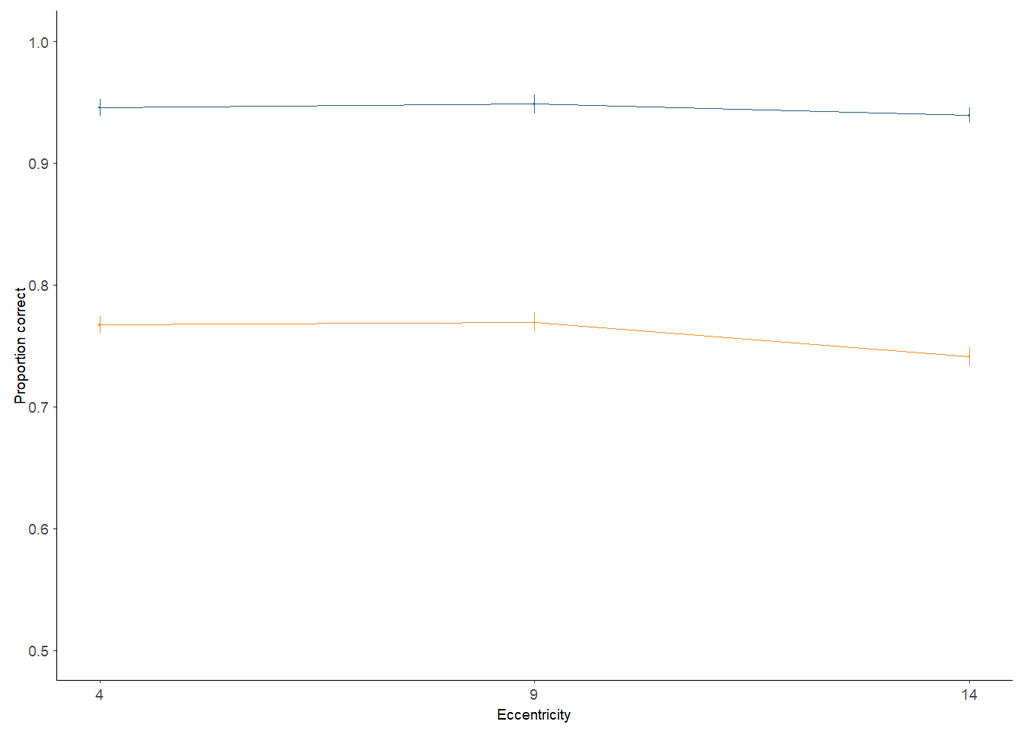

*extract variables:*

### Perception task:

```r
# perceptual Change Detection Task:
results_anova_behav_perc <- func_analysis_01('perception')
```

```
##
## ###########################
## Summary ANOVA
## task: perception
## ###########################
##
##
## Error: ppid
##           Df Sum Sq  Mean Sq F value Pr(>F)
## Residuals 20 0.1186 0.005931
##
## Error: ppid:c_StimN
##           Df  Sum Sq  Mean Sq F value Pr(>F)
## c_StimN    1 0.00678 0.006780    1.33  0.262
## Residuals 20 0.10196 0.005098
##
## Error: ppid:c_Ecc
##           Df Sum Sq Mean Sq F value   Pr(>F)
## c_Ecc      2 0.1004 0.05021   11.85 9.08e-05 ***
## Residuals 40 0.1695 0.00424
## ---
## Signif. codes:  0 '***' 0.001 '**' 0.01 '*' 0.05 '.' 0.1 ' ' 1
##
## Error: ppid:c_StimN:c_Ecc
##               Df  Sum Sq  Mean Sq F value Pr(>F)
## c_StimN:c_Ecc  2 0.00884 0.004422   1.114  0.338
## Residuals     40 0.15876 0.003969
##
## ###########################
## Results post-hoc t test
## task: perception
## ###########################
##
## # A tibble: 3 x 15
##   estimate .y.     group1 group2    n1    n2 statistic        p    df conf.low
## *    <dbl> <chr>   <chr>  <chr>  <int> <int>     <dbl>    <dbl> <dbl>    <dbl>
## 1  0.00768 meanAcc 4      9         21    21     0.608 0.55        20  -0.0187
## 2  0.0630  meanAcc 4      14        21    21     4.31  0.000345    20   0.0325
## 3  0.0554  meanAcc 9      14        21    21     3.61  0.002       20   0.0233
## # ... with 5 more variables: conf.high <dbl>, method <chr>, alternative <chr>,
## #   p.adj <dbl>, p.adj.signif <chr>
## # A tibble: 1 x 3
##     `4`  `14`   `9`
##   <dbl> <dbl> <dbl>
## 1 0.958 0.895 0.950
```

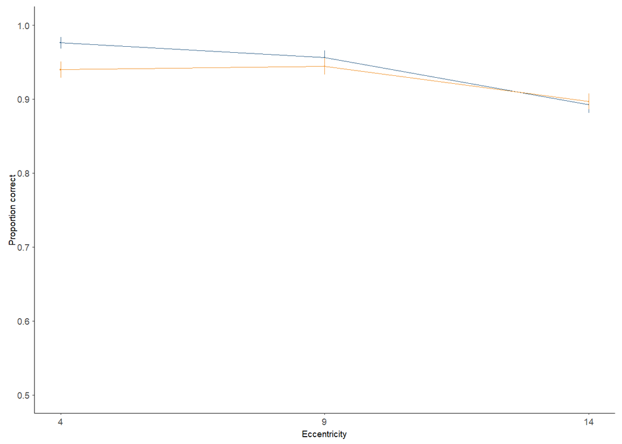

```r
func_analysis_01 <-
function (condition)
{
    if (condition == "experiment") {
        data2analyze <- data_behav %>% drop_na()
    }
    else {
        data2analyze <- data_behav
    }
    c1.aov <- data2analyze %>% filter(BlockStyle == condition) %>%
        group_by(ppid, c_StimN, c_Ecc) %>% summarise(meanAcc = mean(c_ResponseCorrect)) %>%
        ungroup() %>% select("meanAcc", "c_StimN", "c_Ecc", "ppid")
    c1.reduced <- c1.aov %>% pivot_wider(names_from = c(c_StimN,
        c_Ecc), values_from = meanAcc, names_prefix = "cond_") %>%
        select(., contains("cond_"))
    ci_cm <- cm.ci(data.frame = c1.reduced, conf.level = 2 *
        (pnorm(1, 0, 1) - 0.5), difference = TRUE)
    aov.srt <- aov(meanAcc ~ c_StimN * c_Ecc + Error(ppid/(c_StimN *
        c_Ecc)), data = c1.aov)
    results = list()
    results[["aov.srt"]] <- aov.srt
    print_header(str_c("Summary ANOVA \ntask: ", condition))
    print(summary(aov.srt))
    res_ttest <- data2analyze %>% filter(BlockStyle == condition) %>%
        group_by(ppid, c_Ecc) %>% summarise(meanAcc = mean(c_ResponseCorrect)) %>%
        ungroup() %>% pairwise_t_test(meanAcc ~ c_Ecc, paired = TRUE,
        p.adjust.method = "bonferroni", detailed = TRUE)
    print_header(str_c("Results post-hoc t test\ntask: ", condition))
    print(res_ttest)
    results[["res_ttest"]] <- res_ttest
    means <- data2analyze %>% filter(BlockStyle == condition) %>%
        select(c_Ecc, ppid, c_ResponseCorrect) %>% group_by(c_Ecc,
        ppid) %>% pivot_wider(id_cols = ppid, names_from = c_Ecc,
        values_from = c_ResponseCorrect, values_fn = mean) %>%
        ungroup() %>% select(!ppid) %>% summarise_all(.funs = c(mean))
    print(means)
    c1.plt <- c1.aov %>% group_by(c_StimN, c_Ecc) %>% summarise(meanAcc = mean(meanAcc)) %>%
        mutate(cond = str_c("cond", c_StimN, c_Ecc, sep = "_"),
            c_Ecc = as.numeric(as.character(c_Ecc))) %>% left_join(as_tibble(ci_cm) %>%
        add_column(cond = rownames(ci_cm)), by = "cond")
    txt_title <- ifelse(condition == "perception", "Perceptual Task",
        "VSTM Task")
    figa <- ggplot(c1.plt, aes(x = c_Ecc, y = meanAcc, ymin = lower,
        ymax = upper, colour = as_factor(c_StimN)))
    figa <- figa + geom_line(size = 0.23584910000000001) + geom_point(shape = 15,
        size = 0.10000000000000001)
    figa <- figa + scale_colour_manual(values = c(defblue, deforange,
        defgrey))
    figa <- figa + scale_fill_manual(values = c(defblue, deforange,
        defgrey))
    figa <- figa + geom_linerange(size = 0.23584910000000001)
    figa <- figa + scale_x_continuous(breaks = c(4, 9, 14))
    figa <- figa + scale_y_continuous(limits = c(0.5, 1))
    figa <- figa + mytheme
    figa <- figa + ylab("Proportion correct") + xlab("Eccentricity")
    figa <- figa + theme(legend.position = c(1.8500000000000001,
        1.1499999999999999))
    plot(figa)
    fname = file.path(path_global, "Plots2022", "Behavior", str_c("behav_perf_anova_",
        condition, ".pdf"))
    ggsave(plot = figa, width = 5/2.54, height = 3.7000000000000002/2.54,
        dpi = 300, filename = fname)
    return(results)
}
```

*extract variables:*

## Analysis 01 - supplement:

**Is there an effect of workload or eccentricity on RT in the VSTM task and in the perception task?**  
This analysis was only conducted to exclude that a speed-acc trade-off is taking place. As we did not instruct participants to answer as fast as possible and due to imprecise temporal measurements of RTs with the VR hard- and software, we do not report this analysis in the paper.

### VSTM Task:

```r
# VSTM task:
func_analysis_03('experiment')
```

```
##
## ###########################
## Summary ANOVA
## task: experiment
## ###########################
##
##
## Error: ppid
##           Df Sum Sq Mean Sq F value Pr(>F)
## Residuals 20  3.355  0.1678
##
## Error: ppid:c_StimN
##           Df Sum Sq Mean Sq F value   Pr(>F)
## c_StimN    1 0.5917  0.5917   52.46 5.23e-07 ***
## Residuals 20 0.2256  0.0113
## ---
## Signif. codes:  0 '***' 0.001 '**' 0.01 '*' 0.05 '.' 0.1 ' ' 1
##
## Error: ppid:c_Ecc
##           Df  Sum Sq  Mean Sq F value   Pr(>F)
## c_Ecc      2 0.04601 0.023007   13.76 2.84e-05 ***
## Residuals 40 0.06689 0.001672
## ---
## Signif. codes:  0 '***' 0.001 '**' 0.01 '*' 0.05 '.' 0.1 ' ' 1
##
## Error: ppid:c_StimN:c_Ecc
##               Df  Sum Sq   Mean Sq F value Pr(>F)
## c_StimN:c_Ecc  2 0.00046 0.0002324   0.174  0.841
## Residuals     40 0.05344 0.0013359
##
## ###########################
## Results post-hoc t test
## task: experiment
## ###########################
##
## # A tibble: 3 x 10
##   .y.    group1 group2    n1    n2 statistic    df        p   p.adj p.adj.signif
## * <chr>  <chr>  <chr>  <int> <int>     <dbl> <dbl>    <dbl>   <dbl> <chr>
## 1 meanRT 4      9         21    21     -1.08    20  2.93e-1 8.79e-1 ns
## 2 meanRT 4      14        21    21     -3.86    20  9.66e-4 3   e-3 **
## 3 meanRT 9      14        21    21     -5.42    20  2.64e-5 7.92e-5 ****
```

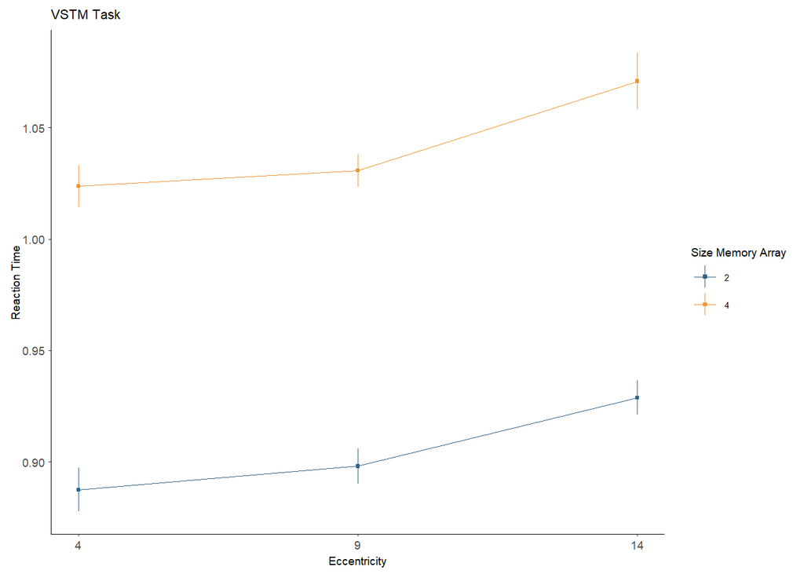

### Perception Task:

```r
# perceptual Change Detection Task:
func_analysis_03('perception')
```

```
##
## ###########################
## Summary ANOVA
## task: perception
## ###########################
##
##
## Error: ppid
##           Df Sum Sq Mean Sq F value Pr(>F)
## Residuals 20  5.755  0.2877
##
## Error: ppid:c_StimN
##           Df Sum Sq  Mean Sq F value Pr(>F)
## c_StimN    1 0.0016 0.001619   0.082  0.777
## Residuals 20 0.3938 0.019692
##
## Error: ppid:c_Ecc
##           Df Sum Sq Mean Sq F value Pr(>F)
## c_Ecc      2 0.0698 0.03490   3.615  0.036 *
## Residuals 40 0.3862 0.00965
## ---
## Signif. codes:  0 '***' 0.001 '**' 0.01 '*' 0.05 '.' 0.1 ' ' 1
##
## Error: ppid:c_StimN:c_Ecc
##               Df  Sum Sq  Mean Sq F value Pr(>F)
## c_StimN:c_Ecc  2 0.00622 0.003111   0.826  0.445
## Residuals     40 0.15059 0.003765
##
## ###########################
## Results post-hoc t test
## task: perception
## ###########################
##
## # A tibble: 3 x 10
##   .y.    group1 group2    n1    n2 statistic    df     p p.adj p.adj.signif
## * <chr>  <chr>  <chr>  <int> <int>     <dbl> <dbl> <dbl> <dbl> <chr>
## 1 meanRT 4      9         21    21     0.543    20 0.593 1     ns
## 2 meanRT 4      14        21    21    -1.79     20 0.089 0.267 ns
## 3 meanRT 9      14        21    21    -2.92     20 0.009 0.026 *
```

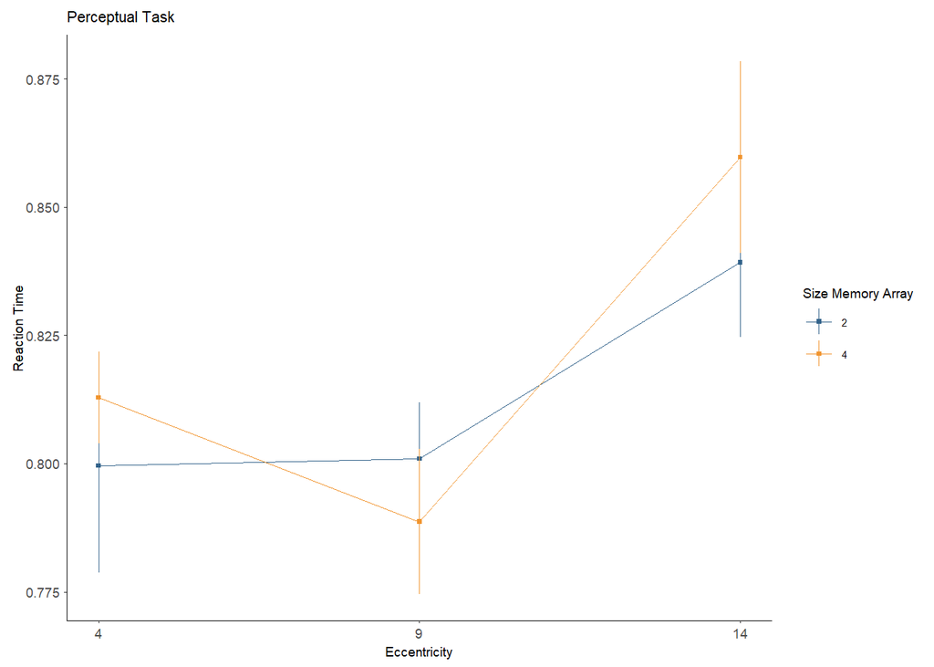

## Analysis 02:

**Is there an effect of workload or eccentricity on mean CDA amplitude in the VSTM task?**

### CDA amplitude (rmANOVA):

```r
results_anova_cda <- func_analysis_05(dep_variable = "CDA_amp_clustertimes")
```

```
##
## ###########################
## Summary ANOVA
## task: experiment
## ###########################
##
##
## Error: ppid
##           Df Sum Sq Mean Sq F value Pr(>F)
## Residuals 20   37.2    1.86
##
## Error: ppid:c_StimN
##           Df Sum Sq Mean Sq F value   Pr(>F)
## c_StimN    1  4.823   4.823   19.84 0.000243 ***
## Residuals 20  4.861   0.243
## ---
## Signif. codes:  0 '***' 0.001 '**' 0.01 '*' 0.05 '.' 0.1 ' ' 1
##
## Error: ppid:c_Ecc
##           Df Sum Sq Mean Sq F value Pr(>F)
## c_Ecc      2  0.272  0.1361    0.84  0.439
## Residuals 40  6.480  0.1620
##
## Error: ppid:c_StimN:c_Ecc
##               Df Sum Sq Mean Sq F value Pr(>F)
## c_StimN:c_Ecc  2  0.915  0.4575    4.55 0.0166 *
## Residuals     40  4.022  0.1005
## ---
## Signif. codes:  0 '***' 0.001 '**' 0.01 '*' 0.05 '.' 0.1 ' ' 1
##
## ###########################
## Results post-hoc t test
## task: experiment
## ###########################
##
## [1] "Contrast between the eccentricity conditions:\n"
## # A tibble: 3 x 15
##   estimate .y.     group1 group2    n1    n2 statistic     p    df conf.low
## *    <dbl> <chr>   <chr>  <chr>  <int> <int>     <dbl> <dbl> <dbl>    <dbl>
## 1  -0.112  meanCDA 4      9         21    21    -1.15  0.266    20   -0.317
## 2  -0.0727 meanCDA 4      14        21    21    -0.828 0.418    20   -0.256
## 3   0.0395 meanCDA 9      14        21    21     0.517 0.611    20   -0.120
## # ... with 5 more variables: conf.high <dbl>, method <chr>, alternative <chr>,
## #   p.adj <dbl>, p.adj.signif <chr>
## [1] "Contrast between MemoryLoad conditions per Eccentricity:\n"
## # A tibble: 3 x 16
##   c_Ecc estimate .y.     group1 group2    n1    n2 statistic        p    df
## * <fct>    <dbl> <chr>   <chr>  <chr>  <int> <int>     <dbl>    <dbl> <dbl>
## 1 4        0.568 meanCDA 2      4         21    21      3.97 0.000751    20
## 2 9        0.445 meanCDA 2      4         21    21      3.99 0.000717    20
## 3 14       0.161 meanCDA 2      4         21    21      1.66 0.113       20
## # ... with 6 more variables: conf.low <dbl>, conf.high <dbl>, method <chr>,
## #   alternative <chr>, p.adj <dbl>, p.adj.signif <chr>
```

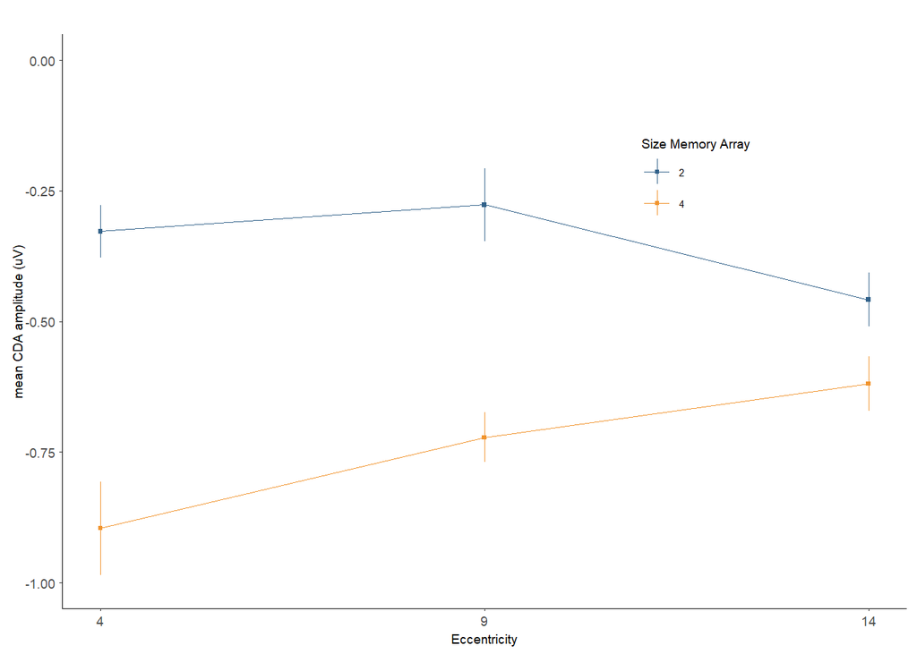

*show source:*

```r
func_analysis_05 <-
function (dep_variable = "CDA_amp_clustertimes")
{
    condition <- "experiment"
    c1.aov <- data_behav %>% mutate(c_Ecc = as_factor(c_Ecc)) %>%
        filter(BlockStyle == condition) %>% group_by(ppid, c_StimN,
        c_Ecc) %>% summarise(across(dep_variable, ~mean(.x, na.rm = T),
        .names = c("meanCDA"))) %>% ungroup() %>% select("meanCDA",
        "c_StimN", "c_Ecc", "ppid")
    c1.reduced <- c1.aov %>% pivot_wider(names_from = c(c_StimN,
        c_Ecc), values_from = meanCDA, names_prefix = "cond_") %>%
        select(., contains("cond_")) %>% drop_na()
    ci_cm <- cm.ci(data.frame = c1.reduced, conf.level = 2 *
        (pnorm(1, 0, 1) - 0.5), difference = TRUE)
    cda_overall_summary <- data_behav %>% mutate(c_Ecc = as_factor(c_Ecc)) %>%
        filter(BlockStyle == condition) %>% drop_na() %>% group_by(ppid) %>%
        summarise(across(CDA_amp_clustertimes, ~mean(.x, na.rm = T),
            .names = c("meanCDA"))) %>% ungroup() %>% summarise(meanCDA_mean = mean(meanCDA),
        meanCDA_sd = sd(meanCDA), meanCDA_ci95lower = ci95lower(meanCDA),
        meanCDA_ci95upper = ci95upper(meanCDA))
    extract_var("cda_sign_cluster_meanamp_mean", cda_overall_summary$meanCDA_mean)
    extract_var("cda_sign_cluster_meanamp_sd", cda_overall_summary$meanCDA_sd)
    extract_var("cda_sign_cluster_meanamp_cilower", cda_overall_summary$meanCDA_ci95lower)
    extract_var("cda_sign_cluster_meanamp_ciupper", cda_overall_summary$meanCDA_ci95upper)
    cda_summary_stimN <- data_behav %>% mutate(c_Ecc = as_factor(c_Ecc)) %>%
        filter(BlockStyle == condition) %>% group_by(ppid, c_StimN) %>%
        summarise(across(dep_variable, ~mean(.x, na.rm = T),
            .names = c("meanCDA"))) %>% group_by(c_StimN) %>%
        summarise(meanCDA_mean = mean(meanCDA), meanCDA_sd = sd(meanCDA))
    extract_var("cda_sign_cluster_meanamp_StimN_2_mean", cda_summary_stimN$meanCDA_mean[cda_summary_stimN$c_StimN ==
        2])
    extract_var("cda_sign_cluster_meanamp_StimN_2_sd", cda_summary_stimN$meanCDA_sd[cda_summary_stimN$c_StimN ==
        2])
    extract_var("cda_sign_cluster_meanamp_StimN_4_mean", cda_summary_stimN$meanCDA_mean[cda_summary_stimN$c_StimN ==
        4])
    extract_var("cda_sign_cluster_meanamp_StimN_4_sd", cda_summary_stimN$meanCDA_sd[cda_summary_stimN$c_StimN ==
        4])
    aov.srt <- aov(meanCDA ~ c_StimN * c_Ecc + Error(ppid/(c_StimN *
        c_Ecc)), data = c1.aov)
    print_header(str_c("Summary ANOVA \ntask: ", condition))
    print(summary(aov.srt))
    res_ttest <- c1.aov %>% group_by(ppid, c_Ecc) %>% summarise(meanCDA = mean(meanCDA)) %>%
        ungroup() %>% pairwise_t_test(meanCDA ~ c_Ecc, paired = TRUE,
        p.adjust.method = "bonferroni", detailed = TRUE)
    print_header(str_c("Results post-hoc t test\ntask: ", condition))
    print("Contrast between the eccentricity conditions:\n")
    print(res_ttest)
    res_ttest_perEcc <- c1.aov %>% group_by(ppid, c_Ecc, c_StimN) %>%
        summarise(meanCDA = mean(meanCDA)) %>% group_by(c_Ecc) %>%
        pairwise_t_test(meanCDA ~ c_StimN, paired = TRUE, p.adjust.method = "bonferroni",
            detailed = TRUE)
    print("Contrast between MemoryLoad conditions per Eccentricity:\n")
    print(res_ttest_perEcc)
    extract_var("cda_exp_Ecc_4_StimN2vsStimN4_t", res_ttest_perEcc$statistic[res_ttest_perEcc$c_Ecc ==
        4])
    extract_var("cda_exp_Ecc_9_StimN2vsStimN4_t", res_ttest_perEcc$statistic[res_ttest_perEcc$c_Ecc ==
        9])
    extract_var("cda_exp_Ecc_14_StimN2vsStimN4_t", res_ttest_perEcc$statistic[res_ttest_perEcc$c_Ecc ==
        14])
    extract_var("cda_exp_Ecc_4_StimN2vsStimN4_p", res_ttest_perEcc$p[res_ttest_perEcc$c_Ecc ==
        4])
    extract_var("cda_exp_Ecc_9_StimN2vsStimN4_p", res_ttest_perEcc$p[res_ttest_perEcc$c_Ecc ==
        9])
    extract_var("cda_exp_Ecc_14_StimN2vsStimN4_p", res_ttest_perEcc$p[res_ttest_perEcc$c_Ecc ==
        14])
    extract_var("cda_exp_Ecc_4_StimN2vsStimN4_df", res_ttest_perEcc$df[res_ttest_perEcc$c_Ecc ==
        4])
    extract_var("cda_exp_Ecc_9_StimN2vsStimN4_df", res_ttest_perEcc$df[res_ttest_perEcc$c_Ecc ==
        9])
    extract_var("cda_exp_Ecc_14_StimN2vsStimN4_df", res_ttest_perEcc$df[res_ttest_perEcc$c_Ecc ==
        14])
    extract_var("cda_exp_Ecc_4_StimN2vsStimN4_diff", res_ttest_perEcc$estimate[res_ttest_perEcc$c_Ecc ==
        4])
    extract_var("cda_exp_Ecc_9_StimN2vsStimN4_diff", res_ttest_perEcc$estimate[res_ttest_perEcc$c_Ecc ==
        9])
    extract_var("cda_exp_Ecc_14_StimN2vsStimN4_diff", res_ttest_perEcc$estimate[res_ttest_perEcc$c_Ecc ==
        14])
    extract_var("cda_exp_Ecc_4_StimN2vsStimN4_ci95upper", res_ttest_perEcc$conf.high[res_ttest_perEcc$c_Ecc ==
        4])
    extract_var("cda_exp_Ecc_9_StimN2vsStimN4_ci95upper", res_ttest_perEcc$conf.high[res_ttest_perEcc$c_Ecc ==
        9])
    extract_var("cda_exp_Ecc_14_StimN2vsStimN4_ci95upper", res_ttest_perEcc$conf.high[res_ttest_perEcc$c_Ecc ==
        14])
    extract_var("cda_exp_Ecc_4_StimN2vsStimN4_ci95lower", res_ttest_perEcc$conf.low[res_ttest_perEcc$c_Ecc ==
        4])
    extract_var("cda_exp_Ecc_9_StimN2vsStimN4_ci95lower", res_ttest_perEcc$conf.low[res_ttest_perEcc$c_Ecc ==
        9])
    extract_var("cda_exp_Ecc_14_StimN2vsStimN4_ci95lower", res_ttest_perEcc$conf.low[res_ttest_perEcc$c_Ecc ==
        14])
    c1.plt <- c1.aov %>% group_by(c_StimN, c_Ecc) %>% summarise(meanCDA = mean(meanCDA,
        na.rm = T)) %>% mutate(cond = str_c("cond", c_StimN,
        c_Ecc, sep = "_"), c_Ecc = as.numeric(as.character(c_Ecc))) %>%
        left_join(as_tibble(ci_cm) %>% add_column(cond = rownames(ci_cm)),
            by = "cond")
    txt_title <- ""
    figa <- ggplot(c1.plt, aes(x = c_Ecc, y = meanCDA, ymin = lower,
        ymax = upper, colour = as_factor(c_StimN)))
    figa <- figa + geom_line(size = 0.23584910000000001) + geom_point(shape = 15,
        size = 0.80000000000000004)
    figa <- figa + scale_colour_manual(values = c(col_LoadLow,
        col_LoadHigh))
    figa <- figa + scale_fill_manual(values = c(defblue, deforange,
        defgrey))
    figa <- figa + geom_linerange(size = 0.23584910000000001)
    figa <- figa + scale_x_continuous(breaks = c(4, 9, 14))
    figa <- figa + scale_y_continuous(limits = c(-1, 0))
    figa <- figa + mytheme
    figa <- figa + ylab("mean CDA amplitude (uV)") + xlab("Eccentricity")
    figa <- figa + labs(title = txt_title, color = "Size Memory Array")
    figa <- figa + theme(legend.position = c(0.75, 0.75))
    fname = file.path(path_global, "Plots2022", "CDA", "stimon",
        "CDA_anova_plot.pdf")
    ggsave(plot = figa, width = 4/2.54, height = 5/2.54, dpi = 300,
        filename = fname)
    plot(figa)
    return(aov.srt)
}
```

*extract variables:*

### Analysis 02 - Supplement 1: CDA amplitude (lmer):

A multilevel model confirms the results of the rmANOVA:

```r
func_analysis_07('experiment', dep_variable = 'CDA_amp_clustertimes')
```

```
##
## ###########################
## Summary glmer
## CDA_amp_clustertimes ~ MemLoad * Eccentricity
## task: experiment
## ###########################
```

```
## Linear mixed model fit by REML. t-tests use Satterthwaite's method [
## lmerModLmerTest]
## Formula: formula
##    Data: data_filtered
##
## REML criterion at convergence: 71953.7
##
## Scaled residuals:
##     Min      1Q  Median      3Q     Max
## -4.2325 -0.6484  0.0073  0.6542  4.8097
##
## Random effects:
##  Groups   Name        Variance Std.Dev.
##  ppid     (Intercept)  0.2936  0.5418
##  Residual             12.5918  3.5485
## Number of obs: 13384, groups:  ppid, 21
##
## Fixed effects:
##                        Estimate Std. Error         df t value Pr(>|t|)
## (Intercept)          -7.660e-01  1.402e-01  3.491e+01  -5.463 3.98e-06 ***
## load_contrast         5.034e-01  1.064e-01  1.336e+04   4.730 2.27e-06 ***
## c_Ecc1               -1.286e-01  1.072e-01  1.336e+04  -1.200   0.2303
## c_Ecc3                1.676e-01  1.058e-01  1.336e+04   1.584   0.1133
## load_contrast:c_Ecc1  8.108e-02  1.512e-01  1.336e+04   0.536   0.5918
## load_contrast:c_Ecc3 -3.541e-01  1.495e-01  1.336e+04  -2.369   0.0179 *
## ---
## Signif. codes:  0 '***' 0.001 '**' 0.01 '*' 0.05 '.' 0.1 ' ' 1
##
## Correlation of Fixed Effects:
##             (Intr) ld_cnt c_Ecc1 c_Ecc3 l_:_E1
## load_cntrst -0.380
## c_Ecc1      -0.378  0.498
## c_Ecc3      -0.383  0.504  0.501
## ld_cntr:_E1  0.268 -0.704 -0.709 -0.355
## ld_cntr:_E3  0.271 -0.712 -0.354 -0.708  0.501
```

*show source:*

```r
func_analysis_07 <-
function (condition, dep_variable)
{
    condition <- "experiment"
    data_filtered <- data_behav %>% drop_na() %>% filter(BlockStyle ==
        condition) %>% select(contains(c("ppid", "c_StimN", "c_Ecc",
        dep_variable))) %>% mutate(c_Ecc = as_factor(c_Ecc))
    contrasts(data_filtered$c_Ecc) <- contr.treatment(3, base = 2)
    data_filtered$load_contrast <- ifelse(data_filtered$c_StimN ==
        2, 1, 0)
    glmer.family = ifelse(dep_variable == "c_ResponseCorrect",
        "binomial", "gaussian")
    formula <- as.formula(str_c(dep_variable, "~ load_contrast*c_Ecc + (1|ppid)"))
    m1 <- lmer(formula, data = data_filtered)
    print_header(str_c("Summary glmer\n", dep_variable, " ~ MemLoad * Eccentricity\n",
        "task: ", condition))
    summary(m1)
}
```

### Analysis 03: PNP amplitude (rmANOVA):

Testing the effects of *memory load* and *eccentricity* on the mean **PNP amplitude** (see [Papaioannou & Luck, 2020](https://onlinelibrary.wiley.com/doi/abs/10.1111/psyp.13532))

```r
results_anova_pnp <- func_analysis_09(dep_variable = "PNP_amp_clustertimes")
```

```
##
## ###########################
## Summary ANOVA
## task: experiment
## ###########################
##
##
## Error: ppid
##           Df Sum Sq Mean Sq F value Pr(>F)
## Residuals 20  38.29   1.914
##
## Error: ppid:c_StimN
##           Df Sum Sq Mean Sq F value Pr(>F)
## c_StimN    1 0.0013  0.0013   0.011  0.917
## Residuals 20 2.3327  0.1166
##
## Error: ppid:c_Ecc
##           Df Sum Sq Mean Sq F value   Pr(>F)
## c_Ecc      2  6.531   3.266   14.93 1.43e-05 ***
## Residuals 40  8.747   0.219
## ---
## Signif. codes:  0 '***' 0.001 '**' 0.01 '*' 0.05 '.' 0.1 ' ' 1
##
## Error: ppid:c_StimN:c_Ecc
##               Df Sum Sq Mean Sq F value Pr(>F)
## c_StimN:c_Ecc  2  0.096 0.04775   0.442  0.646
## Residuals     40  4.321 0.10802
##
## ###########################
## Results post-hoc t test
## task: experiment
## ###########################
##
## # A tibble: 3 x 10
##   .y.     group1 group2    n1    n2 statistic    df        p p.adj p.adj.signif
## * <chr>   <chr>  <chr>  <int> <int>     <dbl> <dbl>    <dbl> <dbl> <chr>
## 1 meanPNP 4      9         21    21     -4.20    20 0.000443 0.001 **
## 2 meanPNP 4      14        21    21     -4.32    20 0.000334 0.001 **
## 3 meanPNP 9      14        21    21     -1.43    20 0.169    0.507 ns
```

## Analysis 04:

**Is there an effect of workload or eccentricity on mean lateralized alpha power in the VSTM task?** See paper for specifics of parameters re. frequency band, ROI, and time window that were used to calculate mean lateralized power (power **contralaterally - ipsilaterally**)

### lat. alpha power (rmANOVA):

```r
results_anova_alphalat <- func_analysis_06()
```

```
##
## ###########################
## Summary ANOVA
## task: experiment
## ###########################
##
##
## Error: ppid
##           Df    Sum Sq  Mean Sq F value Pr(>F)
## Residuals 20 9.419e-18 4.71e-19
##
## Error: ppid:c_StimN
##           Df    Sum Sq   Mean Sq F value Pr(>F)
## c_StimN    1 5.670e-20 5.665e-20   1.248  0.277
## Residuals 20 9.079e-19 4.539e-20
##
## Error: ppid:c_Ecc
##           Df    Sum Sq   Mean Sq F value Pr(>F)
## c_Ecc      2 5.030e-20 2.515e-20   0.402  0.672
## Residuals 40 2.503e-18 6.258e-20
##
## Error: ppid:c_StimN:c_Ecc
##               Df    Sum Sq   Mean Sq F value Pr(>F)
## c_StimN:c_Ecc  2 2.020e-19 1.011e-19   0.675  0.515
## Residuals     40 5.988e-18 1.497e-19
##
## ###########################
## Results post-hoc t test
## task: experiment
## ###########################
##
## # A tibble: 3 x 10
##   .y.       group1 group2    n1    n2 statistic    df     p p.adj p.adj.signif
## * <chr>     <chr>  <chr>  <int> <int>     <dbl> <dbl> <dbl> <dbl> <chr>
## 1 meanAlpha 4      9         21    21    -1.37     20 0.187 0.561 ns
## 2 meanAlpha 4      14        21    21    -0.254    20 0.802 1     ns
## 3 meanAlpha 9      14        21    21     0.514    20 0.613 1     ns
```

*show source:*

```r
func_analysis_06 <-
function ()
{
    condition <- "experiment"
    c1.aov <- data_behav %>% drop_na() %>% filter(BlockStyle ==
        "experiment") %>% group_by(ppid, c_StimN, c_Ecc) %>%
        summarise(meanAlpha = mean(alphapwr_diff_retent, na.rm = TRUE)) %>%
        ungroup() %>% select("meanAlpha", "c_StimN", "c_Ecc",
        "ppid")
    c1.reduced <- c1.aov %>% pivot_wider(names_from = c(c_StimN,
        c_Ecc), values_from = meanAlpha, names_prefix = "cond_") %>%
        select(., contains("cond_"))
    ci_cm <- cm.ci(data.frame = c1.reduced, conf.level = 2 *
        (pnorm(1, 0, 1) - 0.5), difference = TRUE)
    aov.srt <- aov(meanAlpha ~ c_StimN * c_Ecc + Error(ppid/(c_StimN *
        c_Ecc)), data = c1.aov)
    print_header(str_c("Summary ANOVA \ntask: ", condition))
    print(summary(aov.srt))
    res_ttest <- c1.aov %>% group_by(ppid, c_Ecc) %>% summarise(meanAlpha = mean(meanAlpha)) %>%
        ungroup() %>% pairwise_t_test(meanAlpha ~ c_Ecc, paired = TRUE,
        p.adjust.method = "bonferroni")
    print_header(str_c("Results post-hoc t test\ntask: ", condition))
    print(res_ttest)
    c1.plt <- c1.aov %>% group_by(c_StimN, c_Ecc) %>% summarise(meanAlpha = mean(meanAlpha)) %>%
        mutate(cond = str_c("cond", c_StimN, c_Ecc, sep = "_"),
            c_Ecc = as.numeric(as.character(c_Ecc))) %>% left_join(as_tibble(ci_cm) %>%
        add_column(cond = rownames(ci_cm)), by = "cond")
    txt_title <- ifelse(condition == "perception", "Perceptual Task",
        "VSTM Task")
    figa <- ggplot(c1.plt, aes(x = c_Ecc, y = meanAlpha, ymin = lower,
        ymax = upper, colour = as_factor(c_StimN)))
    figa <- figa + geom_line(size = 0.23584910000000001) + geom_point(shape = 15,
        size = 0.80000000000000004)
    figa <- figa + scale_colour_manual(values = c(defblue, deforange,
        defgrey))
    figa <- figa + scale_fill_manual(values = c(defblue, deforange,
        defgrey))
    figa <- figa + geom_linerange(size = 0.23584910000000001)
    figa <- figa + scale_x_continuous(breaks = c(4, 9, 14))
    figa <- figa + mytheme
    figa <- figa + ylab("mean alpha power (au)") + xlab("Eccentricity")
    figa <- figa + labs(title = txt_title, color = "Size Memory Array")
    figa <- figa + theme(legend.position = "right")
    figa
    return(aov.srt)
}
```

### Analysis 04 - Supplement 1: lat. alpha power (lmer):

A multilevel model confirms the results of the rmANOVA:

```r
func_analysis_10('experiment', dep_variable = 'alpha_pwr')
```

```
##
## ###########################
## Summary glmer
## alpha_pwr ~ MemLoad * Eccentricity
## task: experiment
## ###########################
```

```
## Linear mixed model fit by REML. t-tests use Satterthwaite's method [
## lmerModLmerTest]
## Formula: alphapwr_diff_retent ~ load_contrast * c_Ecc + (1 | ppid)
##    Data: data_filtered
##
## REML criterion at convergence: -491060.1
##
## Scaled residuals:
##      Min       1Q   Median       3Q      Max
## -12.0705  -0.2375   0.0158   0.2520  20.8743
##
## Random effects:
##  Groups   Name        Variance  Std.Dev.
##  ppid     (Intercept) 6.797e-20 2.607e-10
##  Residual             6.657e-18 2.580e-09
## Number of obs: 13384, groups:  ppid, 21
##
## Fixed effects:
##                        Estimate Std. Error         df t value Pr(>|t|)
## (Intercept)          -2.648e-10  7.900e-11  5.999e-03  -3.352    0.974
## load_contrast         1.017e-10  7.738e-11  6.000e-03   1.315    0.979
## c_Ecc1                4.388e-11  7.793e-11  6.000e-03   0.563    0.984
## c_Ecc3               -1.524e-11  7.692e-11  6.000e-03  -0.198    0.990
## load_contrast:c_Ecc1 -1.741e-10  1.099e-10  6.000e-03  -1.583    0.978
## load_contrast:c_Ecc3 -1.006e-11  1.087e-10  6.000e-03  -0.093    0.994
##
## Correlation of Fixed Effects:
##             (Intr) ld_cnt c_Ecc1 c_Ecc3 l_:_E1
## load_cntrst -0.491
## c_Ecc1      -0.488  0.498
## c_Ecc3      -0.494  0.504  0.501
## ld_cntr:_E1  0.346 -0.704 -0.709 -0.355
## ld_cntr:_E3  0.350 -0.712 -0.354 -0.708  0.501
```

## Analysis 05:

**Is there an effect of stimulus eccentricity on the (max) decoding performance?

### Sensor space decoding (rmANOVA):

```r
results_anova_decod_ss <- func_analysis_12()
```

```
##
## ###########################
## Summary ANOVA
## task: experiment
## ###########################
##
##
## Error: ppid
##           Df  Sum Sq  Mean Sq F value Pr(>F)
## Residuals 20 0.08433 0.004216
##
## Error: ppid:c_Ecc
##           Df  Sum Sq  Mean Sq F value Pr(>F)
## c_Ecc      2 0.00592 0.002962    2.33   0.11
## Residuals 40 0.05086 0.001272
##
## ###########################
## Results post-hoc t test
## task: experiment
## ###########################
##
## # A tibble: 3 x 10
##   .y.         group1 group2    n1    n2 statistic    df     p p.adj p.adj.signif
## * <chr>       <chr>  <chr>  <int> <int>     <dbl> <dbl> <dbl> <dbl> <chr>
## 1 mean_decod~ 4      9         21    21     0.882    20 0.388 1     ns
## 2 mean_decod~ 4      14        21    21     2.16     20 0.043 0.13  ns
## 3 mean_decod~ 9      14        21    21     1.22     20 0.235 0.705 ns
```

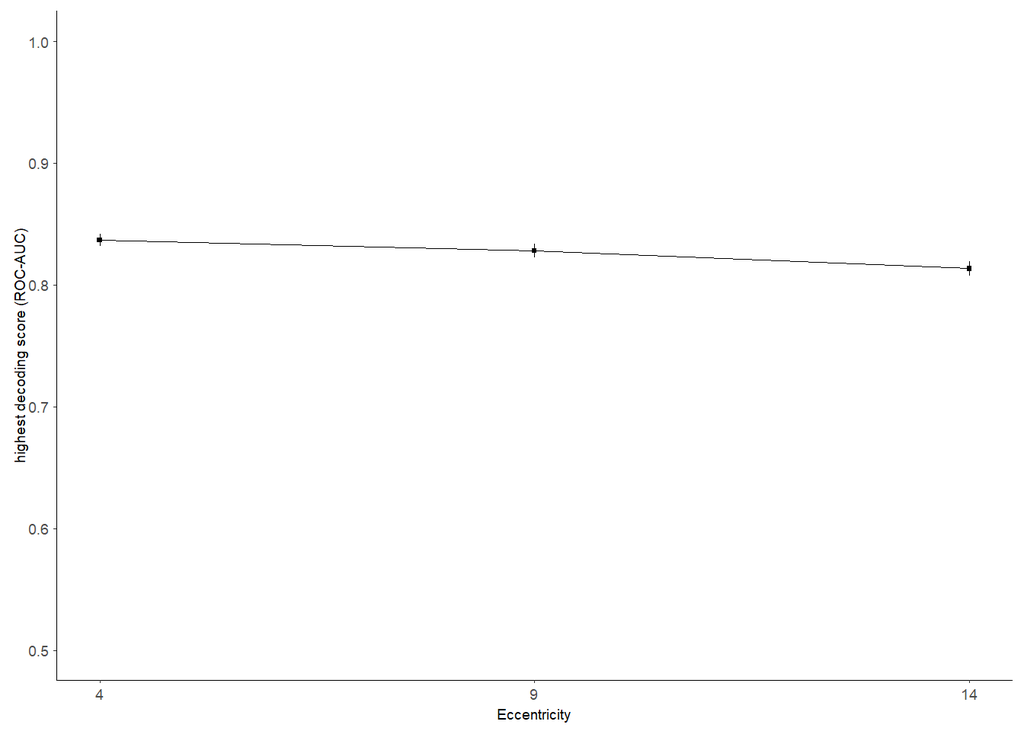

*show source:*

```r
func_analysis_12 <-
function ()
{
    condition <- "experiment"
    c1.aov <- data_behav %>% mutate(c_Ecc = as_factor(c_Ecc)) %>%
        filter(BlockStyle == condition) %>% group_by(ppid, c_Ecc) %>%
        summarise(mean_decodscore = mean(maxDecodScore_sensorspace,
            na.rm = T)) %>% ungroup() %>% select("mean_decodscore",
        "c_Ecc", "ppid")
    c1.reduced <- c1.aov %>% pivot_wider(names_from = c(c_Ecc),
        values_from = mean_decodscore, names_prefix = "cond_") %>%
        select(., contains("cond_")) %>% drop_na()
    ci_cm <- cm.ci(data.frame = c1.reduced, conf.level = 2 *
        (pnorm(1, 0, 1) - 0.5), difference = TRUE)
    aov.srt <- aov(mean_decodscore ~ c_Ecc + Error(ppid/c_Ecc),
        data = c1.aov)
    print_header(str_c("Summary ANOVA \ntask: ", condition))
    print(summary(aov.srt))
    res_ttest <- c1.aov %>% pairwise_t_test(mean_decodscore ~
        c_Ecc, paired = TRUE, p.adjust.method = "bonferroni")
    print_header(str_c("Results post-hoc t test\ntask: ", condition))
    print(res_ttest)
    c1.plt <- c1.aov %>% group_by(c_Ecc) %>% summarise(mean_decodscore = mean(mean_decodscore,
        na.rm = T)) %>% mutate(cond = str_c("cond", c_Ecc, sep = "_"),
        c_Ecc = as.numeric(as.character(c_Ecc))) %>% left_join(as_tibble(ci_cm) %>%
        add_column(cond = rownames(ci_cm)), by = "cond")
    txt_title <- ""
    figa <- ggplot(c1.plt, aes(x = c_Ecc, y = mean_decodscore,
        ymin = lower, ymax = upper), colour = "blue")
    figa <- figa + geom_line(size = 0.23584910000000001) + geom_point(shape = 15,
        size = 0.80000000000000004)
    figa <- figa + scale_fill_manual(values = c(defblue, deforange,
        defgrey))
    figa <- figa + geom_linerange(size = 0.23584910000000001)
    figa <- figa + scale_x_continuous(breaks = c(4, 9, 14))
    figa <- figa + scale_y_continuous(limits = c(0.5, 1))
    figa <- figa + mytheme
    figa <- figa + ylab("highest decoding score (ROC-AUC)") +
        xlab("Eccentricity")
    figa <- figa + theme(legend.position = c(0.84999999999999998,
        1))
    plot(figa)
    return(aov.srt)
}
```

### CSP decoding (rmANOVA):

```r
results_anova_decod_csp <- func_analysis_14()
```

```
##
## ###########################
## Summary ANOVA
## task: experiment
## ###########################
##
##
## Error: ppid
##           Df  Sum Sq  Mean Sq F value Pr(>F)
## Residuals 20 0.08843 0.004422
##
## Error: ppid:c_Ecc
##           Df   Sum Sq   Mean Sq F value Pr(>F)
## c_Ecc      2 0.000233 0.0001166   0.194  0.825
## Residuals 40 0.024103 0.0006026
##
## ###########################
## Results post-hoc t test
## task: experiment
## ###########################
##
## # A tibble: 3 x 10
##   .y.         group1 group2    n1    n2 statistic    df     p p.adj p.adj.signif
## * <chr>       <chr>  <chr>  <int> <int>     <dbl> <dbl> <dbl> <dbl> <chr>
## 1 mean_decod~ 4      9         21    21    -0.490    20 0.629     1 ns
## 2 mean_decod~ 4      14        21    21     0.161    20 0.873     1 ns
## 3 mean_decod~ 9      14        21    21     0.533    20 0.6       1 ns
```

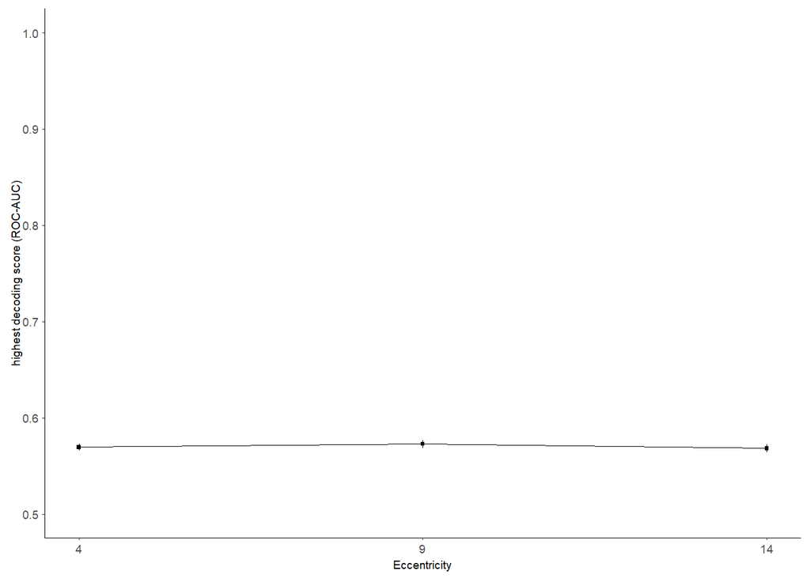

*show source:*

```r
func_analysis_14 <-
function ()
{
    condition <- "experiment"
    c1.aov <- data_behav %>% mutate(c_Ecc = as_factor(c_Ecc)) %>%
        filter(BlockStyle == condition) %>% group_by(ppid, c_Ecc) %>%
        summarise(mean_decodscore = mean(maxDecodScore_csp, na.rm = T)) %>%
        ungroup() %>% select("mean_decodscore", "c_Ecc", "ppid")
    c1.reduced <- c1.aov %>% pivot_wider(names_from = c(c_Ecc),
        values_from = mean_decodscore, names_prefix = "cond_") %>%
        select(., contains("cond_")) %>% drop_na()
    ci_cm <- cm.ci(data.frame = c1.reduced, conf.level = 2 *
        (pnorm(1, 0, 1) - 0.5), difference = TRUE)
    aov.srt <- aov(mean_decodscore ~ c_Ecc + Error(ppid/c_Ecc),
        data = c1.aov)
    print_header(str_c("Summary ANOVA \ntask: ", condition))
    print(summary(aov.srt))
    res_ttest <- c1.aov %>% pairwise_t_test(mean_decodscore ~
        c_Ecc, paired = TRUE, p.adjust.method = "bonferroni")
    print_header(str_c("Results post-hoc t test\ntask: ", condition))
    print(res_ttest)
    c1.plt <- c1.aov %>% group_by(c_Ecc) %>% summarise(mean_decodscore = mean(mean_decodscore,
        na.rm = T)) %>% mutate(cond = str_c("cond", c_Ecc, sep = "_"),
        c_Ecc = as.numeric(as.character(c_Ecc))) %>% left_join(as_tibble(ci_cm) %>%
        add_column(cond = rownames(ci_cm)), by = "cond")
    txt_title <- ""
    figa <- ggplot(c1.plt, aes(x = c_Ecc, y = mean_decodscore,
        ymin = lower, ymax = upper), colour = "blue")
    figa <- figa + geom_line(size = 0.23584910000000001) + geom_point(shape = 15,
        size = 0.80000000000000004)
    figa <- figa + scale_fill_manual(values = c(defblue, deforange,
        defgrey))
    figa <- figa + geom_linerange(size = 0.23584910000000001)
    figa <- figa + scale_x_continuous(breaks = c(4, 9, 14))
    figa <- figa + scale_y_continuous(limits = c(0.5, 1))
    figa <- figa + mytheme
    figa <- figa + ylab("highest decoding score (ROC-AUC)") +
        xlab("Eccentricity")
    figa <- figa + theme(legend.position = c(0.84999999999999998,
        1))
    plot(figa)
    return(aov.srt)
}
```

## Analysis 05 - supplement:

**Is there an effect of stimulus eccentricity on the time of the max. decoding performance?

### Sensor space decoding (rmANOVA):

```r
results_anova_decod_ss_time <- func_analysis_13()
```

```
##
## ###########################
## Summary ANOVA
## task: experiment
## ###########################
##
##
## Error: ppid
##           Df Sum Sq Mean Sq F value Pr(>F)
## Residuals 20  6.636  0.3318
##
## Error: ppid:c_Ecc
##           Df Sum Sq Mean Sq F value Pr(>F)
## c_Ecc      2  0.462  0.2311   1.004  0.375
## Residuals 40  9.206  0.2301
##
## ###########################
## Results post-hoc t test
## task: experiment
## ###########################
##
## # A tibble: 3 x 10
##   .y.         group1 group2    n1    n2 statistic    df     p p.adj p.adj.signif
## * <chr>       <chr>  <chr>  <int> <int>     <dbl> <dbl> <dbl> <dbl> <chr>
## 1 mean_decod~ 4      9         21    21    -0.849    20 0.406  1    ns
## 2 mean_decod~ 4      14        21    21    -1.42     20 0.17   0.51 ns
## 3 mean_decod~ 9      14        21    21    -0.481    20 0.636  1    ns
```

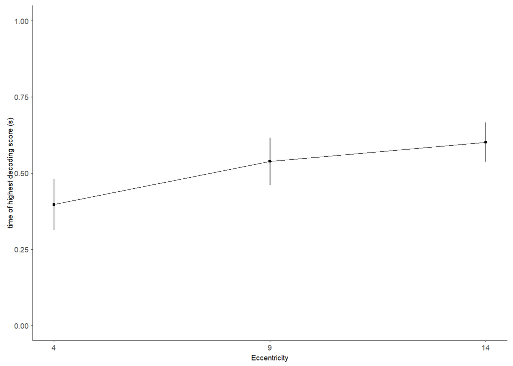

*show source:*

```r
func_analysis_13 <-
function ()
{
    condition <- "experiment"
    c1.aov <- data_behav %>% mutate(c_Ecc = as_factor(c_Ecc)) %>%
        filter(BlockStyle == condition) %>% group_by(ppid, c_Ecc) %>%
        summarise(mean_decodscoretime = mean(maxDecodScoreTime_sensorspace,
            na.rm = T)) %>% ungroup() %>% select("mean_decodscoretime",
        "c_Ecc", "ppid")
    c1.reduced <- c1.aov %>% pivot_wider(names_from = c(c_Ecc),
        values_from = mean_decodscoretime, names_prefix = "cond_") %>%
        select(., contains("cond_")) %>% drop_na()
    ci_cm <- cm.ci(data.frame = c1.reduced, conf.level = 2 *
        (pnorm(1, 0, 1) - 0.5), difference = TRUE)
    aov.srt <- aov(mean_decodscoretime ~ c_Ecc + Error(ppid/c_Ecc),
        data = c1.aov)
    print_header(str_c("Summary ANOVA \ntask: ", condition))
    print(summary(aov.srt))
    res_ttest <- c1.aov %>% pairwise_t_test(mean_decodscoretime ~
        c_Ecc, paired = TRUE, p.adjust.method = "bonferroni")
    print_header(str_c("Results post-hoc t test\ntask: ", condition))
    print(res_ttest)
    c1.plt <- c1.aov %>% group_by(c_Ecc) %>% summarise(mean_decodscoretime = mean(mean_decodscoretime,
        na.rm = T)) %>% mutate(cond = str_c("cond", c_Ecc, sep = "_"),
        c_Ecc = as.numeric(as.character(c_Ecc))) %>% left_join(as_tibble(ci_cm) %>%
        add_column(cond = rownames(ci_cm)), by = "cond")
    txt_title <- ""
    figa <- ggplot(c1.plt, aes(x = c_Ecc, y = mean_decodscoretime,
        ymin = lower, ymax = upper), colour = "blue")
    figa <- figa + geom_line(size = 0.23584910000000001) + geom_point(shape = 15,
        size = 0.80000000000000004)
    figa <- figa + scale_fill_manual(values = c(defblue, deforange,
        defgrey))
    figa <- figa + geom_linerange(size = 0.23584910000000001)
    figa <- figa + scale_x_continuous(breaks = c(4, 9, 14))
    figa <- figa + scale_y_continuous(limits = c(0, 1))
    figa <- figa + mytheme
    figa <- figa + ylab("time of highest decoding score (s)") +
        xlab("Eccentricity")
    figa <- figa + theme(legend.position = c(0.84999999999999998,
        1))
    plot(figa)
    return(aov.srt)
}
```

### CSP decoding (rmANOVA):

```r
results_anova_decod_csp_time <- func_analysis_15()
```

```
##
## ###########################
## Summary ANOVA
## task: experiment
## ###########################
##
##
## Error: ppid
##           Df Sum Sq Mean Sq F value Pr(>F)
## Residuals 20  4.853  0.2427
##
## Error: ppid:c_Ecc
##           Df Sum Sq Mean Sq F value Pr(>F)
## c_Ecc      2  1.883  0.9415   2.143  0.131
## Residuals 40 17.575  0.4394
##
## ###########################
## Results post-hoc t test
## task: experiment
## ###########################
##
## # A tibble: 3 x 10
##   .y.         group1 group2    n1    n2 statistic    df     p p.adj p.adj.signif
## * <chr>       <chr>  <chr>  <int> <int>     <dbl> <dbl> <dbl> <dbl> <chr>
## 1 mean_decod~ 4      9         21    21    -1.78     20 0.09  0.271 ns
## 2 mean_decod~ 4      14        21    21    -1.49     20 0.151 0.453 ns
## 3 mean_decod~ 9      14        21    21     0.742    20 0.467 1     ns
```

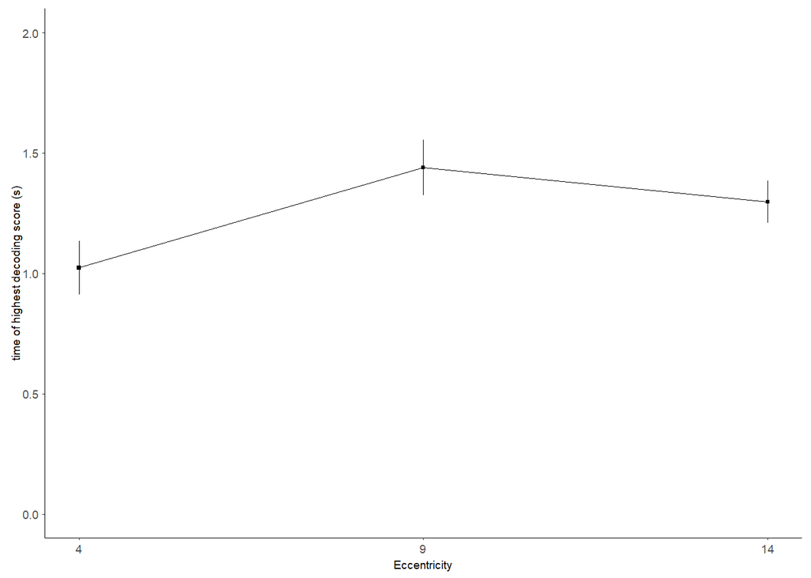

*show source:*

```r
func_analysis_15 <-
function ()
{
    condition <- "experiment"
    c1.aov <- data_behav %>% mutate(c_Ecc = as_factor(c_Ecc)) %>%
        filter(BlockStyle == condition) %>% group_by(ppid, c_Ecc) %>%
        summarise(mean_decodscoretime = mean(maxDecodScoreTime_csp,
            na.rm = T)) %>% ungroup() %>% select("mean_decodscoretime",
        "c_Ecc", "ppid")
    c1.reduced <- c1.aov %>% pivot_wider(names_from = c(c_Ecc),
        values_from = mean_decodscoretime, names_prefix = "cond_") %>%
        select(., contains("cond_")) %>% drop_na()
    ci_cm <- cm.ci(data.frame = c1.reduced, conf.level = 2 *
        (pnorm(1, 0, 1) - 0.5), difference = TRUE)
    aov.srt <- aov(mean_decodscoretime ~ c_Ecc + Error(ppid/c_Ecc),
        data = c1.aov)
    print_header(str_c("Summary ANOVA \ntask: ", condition))
    print(summary(aov.srt))
    res_ttest <- c1.aov %>% pairwise_t_test(mean_decodscoretime ~
        c_Ecc, paired = TRUE, p.adjust.method = "bonferroni")
    print_header(str_c("Results post-hoc t test\ntask: ", condition))
    print(res_ttest)
    c1.plt <- c1.aov %>% group_by(c_Ecc) %>% summarise(mean_decodscoretime = mean(mean_decodscoretime,
        na.rm = T)) %>% mutate(cond = str_c("cond", c_Ecc, sep = "_"),
        c_Ecc = as.numeric(as.character(c_Ecc))) %>% left_join(as_tibble(ci_cm) %>%
        add_column(cond = rownames(ci_cm)), by = "cond")
    txt_title <- ""
    figa <- ggplot(c1.plt, aes(x = c_Ecc, y = mean_decodscoretime,
        ymin = lower, ymax = upper), colour = "blue")
    figa <- figa + geom_line(size = 0.23584910000000001) + geom_point(shape = 15,
        size = 0.80000000000000004)
    figa <- figa + scale_fill_manual(values = c(defblue, deforange,
        defgrey))
    figa <- figa + geom_linerange(size = 0.23584910000000001)
    figa <- figa + scale_x_continuous(breaks = c(4, 9, 14))
    figa <- figa + scale_y_continuous(limits = c(0, 2))
    figa <- figa + mytheme
    figa <- figa + ylab("time of highest decoding score (s)") +
        xlab("Eccentricity")
    figa <- figa + theme(legend.position = c(0.84999999999999998,
        1))
    plot(figa)
    return(aov.srt)
}
```

## Plot correlations:

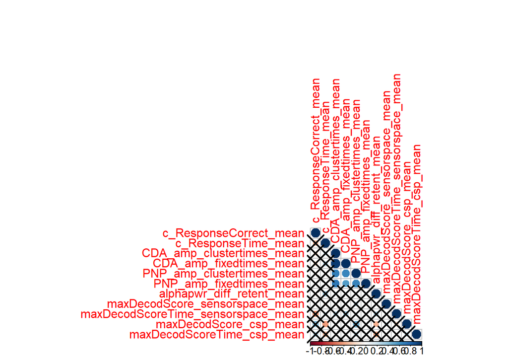

```r
dcor <- data_behav %>%
  filter(BlockStyle == 'experiment') %>%
  select(-trial_num, -block_num, -c_StimN, -c_Ecc, -BlockStyle) %>%
  group_by(ppid) %>%
  summarise_all(.funs = c(mean = ~mean(., na.rm=TRUE))) %>%
  ungroup() %>%
  select(-ppid)

Mcor <- cor(dcor, method="spearman")
Pcor <- cor.mtest(dcor, conf.level=0.95)

corrplot(Mcor, type = 'lower', p.mat = Pcor$p, sig.level = 0.05)
```

# Write out the full data frame:

```r
saveRDS(data_behav,file = file.path(path_r_data, "VME_trialdata.rds"))

variable_doc <- list()

variable_doc[["ppid"]] <-
  "subject identifier"
variable_doc[["trial_num"]] <-
  "trial number (1-10 & 83-92: training, 11-72: perception task, 93-812: vSTM task)"
variable_doc[["block_num"]] <-
  "number of experimental block (1 & 3: training, 2: perception task, 4-13: vSTM task)"
variable_doc[["c_StimN"]] <-
  "Memory Load (aka. number of memory stimuli)"
variable_doc[["c_Ecc"]] <-
  "Eccentricity of the stimulus arrays (in dva)"
variable_doc[["c_ResponseCorrect"]] <-
  "Correctness of response"
variable_doc[["c_ResponseTime"]] <-
  "Response time"
variable_doc[["BlockStyle"]] <-
  "Type of the block (perception task or vSTM task [experiment])"
variable_doc[["CDA_amp_clustertimes"]] <-
  "Mean CDA amplitude, averaged across 5 ROI electrodes and timepoints when overall CDA was sign. different from 0 (as assessed by a CBP test)"
variable_doc[["PNP_amp_clustertimes"]] <-
  "Mean PNP amplitude, averaged across 5 ROI electrodes and timepoints when overall PNP was sign. different from 0 (as assessed by a CBP test)"
variable_doc[["CDA_amp_fixedtimes"]] <-
  "Mean CDA amplitude, averaged across 5 ROI electrodes and timepoints during the time window [0.4-1.45s] used by Hakim et al. (2019)"
variable_doc[["PNP_amp_fixedtimes"]] <-
  "Mean CDA amplitude, averaged across 5 ROI electrodes and timepoints during the time window [0.3–0.444s] used by Papaioannou et al. (2020)"
variable_doc[["alphapwr_diff_retent"]] <-
  "Mean induced alpha power difference (between hemispheres), averaged across 5 ROI electrodes and timepoints when overall alpha power lateralization was sign. different from 0 (as assessed by a CBP test)"
variable_doc[["alphapwr_diff_retent"]] <-
  "Mean induced alpha power difference (between hemispheres), averaged across 5 ROI electrodes and timepoints when overall alpha power lateralization was sign. different from 0 (as assessed by a CBP test)"
variable_doc[["maxDecodScore_sensorspace"]] <-
  "Highest decoding score achieved by the sliding classifier run on the voltage data. One score per eccentricity condition and subject (not per trial)."
variable_doc[["maxDecodScoreTime_sensorspace"]] <-
  "Time (relativ to stimulus onset) of the highest decoding score achieved by the sliding classifier run on the voltage data. One score per eccentricity condition and subject (not per trial)."
variable_doc[["maxDecodScore_csp"]] <-
  "Highest decoding score achieved by the sliding CSP classifier (classification in power space). One score per eccentricity condition and subject (not per trial)."
variable_doc[["maxDecodScore_csp"]] <-
  "Time (relativ to stimulus onset) of the highest decoding score achieved by the sliding CSP classifier (classification in power space). One score per eccentricity condition and subject (not per trial)."



if ((length(names(variable_doc)) != length(colnames(data_behav))) | any(sort(names(variable_doc)) != sort(colnames(data_behav)))) {
  warning("The docu of the variables ('VME_trialdata__variables.json') might be incomplete or wrong.")
}
jsonlite::write_json(variable_doc, file.path(path_r_data, "VME_trialdata__variables.json"), pretty=TRUE)
```